# Lecture [03b] Activity

[figure not shown]

## Question 1

1. Tidy up this data and save it to a tibble. Decide for yourself how to handle season 5 (should it be a single observation or two?). For the first and last aired dates, just store the year as a number.
2. Save the tibble you created to a CSV file named “breaking_bad.csv”.

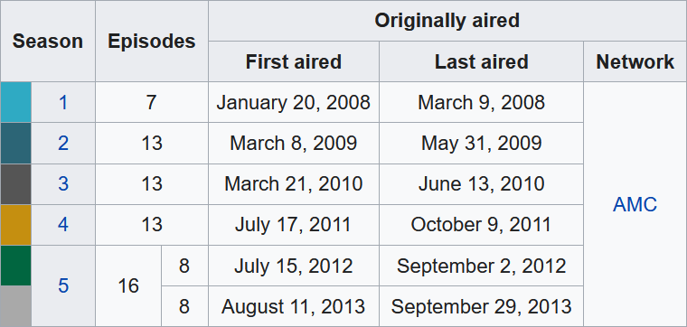

**Answer key**

> **Part (a)**

> Version with one observation for the season five parts

> ```r
> library(tidyverse)
> season <- c(1, 2, 3, 4, 5)
> episodes <- c(7, 13, 13, 13, 16)
> first_air <- c(2008, 2009, 2010, 2011, 2012)
> last_air <- c(2008, 2009, 2010, 2011, 2013)
> network <- "AMC"
> breaking_bad <-
>   tibble(season, episodes, first_air, last_air, network)
> breaking_bad
> ```

> ```
> # A tibble: 5 × 5
>   season episodes first_air last_air network
>    <dbl>    <dbl>     <dbl>    <dbl> <chr>
> 1      1        7      2008     2008 AMC
> 2      2       13      2009     2009 AMC
> 3      3       13      2010     2010 AMC
> 4      4       13      2011     2011 AMC
> 5      5       16      2012     2013 AMC
> ```

> Version with two separate observations for the season five parts

> ```r
> library(tidyverse)
> season <- c(1, 2, 3, 4, 5.1, 5.2)
> episodes <- c(7, 13, 13, 13, 8, 8)
> first_air <- c(2008, 2009, 2010, 2011, 2012, 2013)
> last_air <- c(2008, 2009, 2010, 2011, 2012, 2013)
> network <- "AMC"
> breaking_bad <-
>   tibble(season, episodes, first_air, last_air, network)
> breaking_bad
> ```

> ```
> # A tibble: 6 × 5
>   season episodes first_air last_air network
>    <dbl>    <dbl>     <dbl>    <dbl> <chr>
> 1    1          7      2008     2008 AMC
> 2    2         13      2009     2009 AMC
> 3    3         13      2010     2010 AMC
> 4    4         13      2011     2011 AMC
> 5    5.1        8      2012     2012 AMC
> 6    5.2        8      2013     2013 AMC
> ```

> **Part (b)**

> ```r
> write_csv(breaking_bad, "breaking_bad.csv")
> ```

## Question 2

1. Download the `kaggle_cereal.csv` file from Canvas and save it to your class Project folder.
2. Use {tidyverse} to import this file into R as a tibble named `cereal`, using an argument to make the missing values (coded as `"missing"`) into `NA`s.
3. Run your command again but with the `show_col_types = FALSE` argument to suppress the column specification message.

**Answer key**

> **Part (b)**

> ```r
> cereal <- read_csv("kaggle_cereal.csv", na = "missing")
> cereal
> ```

> ```
> # A tibble: 77 × 8
>    name                      mfr       type  calories sodium carbo sugars rating
>    <chr>                     <chr>     <chr>    <dbl>  <dbl> <dbl>  <dbl>  <dbl>
>  1 100% Bran                 Nabisco   cold        70    130   5        6   68.4
>  2 100% Natural Bran         Quaker O… cold       120     15   8        8   34.0
>  3 All-Bran                  Kelloggs  cold        70    260   7        5   59.4
>  4 All-Bran with Extra Fiber Kelloggs  cold        50    140   8        0   93.7
>  5 Almond Delight            Ralston … cold       110    200  14        8   34.4
>  6 Apple Cinnamon Cheerios   General … cold       110    180  10.5     10   29.5
>  7 Apple Jacks               Kelloggs  cold       110    125  11       14   33.2
>  8 Basic 4                   General … cold       130    210  18        8   37.0
>  9 Bran Chex                 Ralston … cold        90    200  15        6   49.1
> 10 Bran Flakes               Post      cold        90    210  13        5   53.3
> # ℹ 67 more rows
> ```

> ```r
> cereal <- read_csv("kaggle_cereal.csv", na = "missing", show_col_types = FALSE)
> ```

## Question 3

1. Update the `cereal` tibble from Question 2 to make the `type` variable a factor.
2. Tabulate the `type` variable using `data_tabulate()` and plot its discrete distribution using `qplot()`.
3. Describe the `calories` variable using `describe_distribution()` and plot its continuous distribution using `qplot()` and a “histogram” or “boxplot” geom.
4. Plot the covariation of the `calories` and `rating` variables using `qplot()` and a “point” or “jitter” geom.

**Answer key**

> **Part (a)**

> ```r
> cereal$type <- factor(cereal$type)
> cereal
> ```

> ```
> # A tibble: 77 × 8
>    name                      mfr       type  calories sodium carbo sugars rating
>    <chr>                     <chr>     <fct>    <dbl>  <dbl> <dbl>  <dbl>  <dbl>
>  1 100% Bran                 Nabisco   cold        70    130   5        6   68.4
>  2 100% Natural Bran         Quaker O… cold       120     15   8        8   34.0
>  3 All-Bran                  Kelloggs  cold        70    260   7        5   59.4
>  4 All-Bran with Extra Fiber Kelloggs  cold        50    140   8        0   93.7
>  5 Almond Delight            Ralston … cold       110    200  14        8   34.4
>  6 Apple Cinnamon Cheerios   General … cold       110    180  10.5     10   29.5
>  7 Apple Jacks               Kelloggs  cold       110    125  11       14   33.2
>  8 Basic 4                   General … cold       130    210  18        8   37.0
>  9 Bran Chex                 Ralston … cold        90    200  15        6   49.1
> 10 Bran Flakes               Post      cold        90    210  13        5   53.3
> # ℹ 67 more rows
> ```

> **Part (b)**

> ```r
> library(easystats)
> data_tabulate(cereal, type)
> ```

> ```
> type (type) <categorical>
> # total N=77 valid N=77
>
> Value |  N | Raw % | Valid % | Cumulative %
> ------+----+-------+---------+-------------
> cold  | 74 | 96.10 |   96.10 |        96.10
> hot   |  3 |  3.90 |    3.90 |       100.00
> <NA>  |  0 |  0.00 |    <NA> |         <NA>
> ```

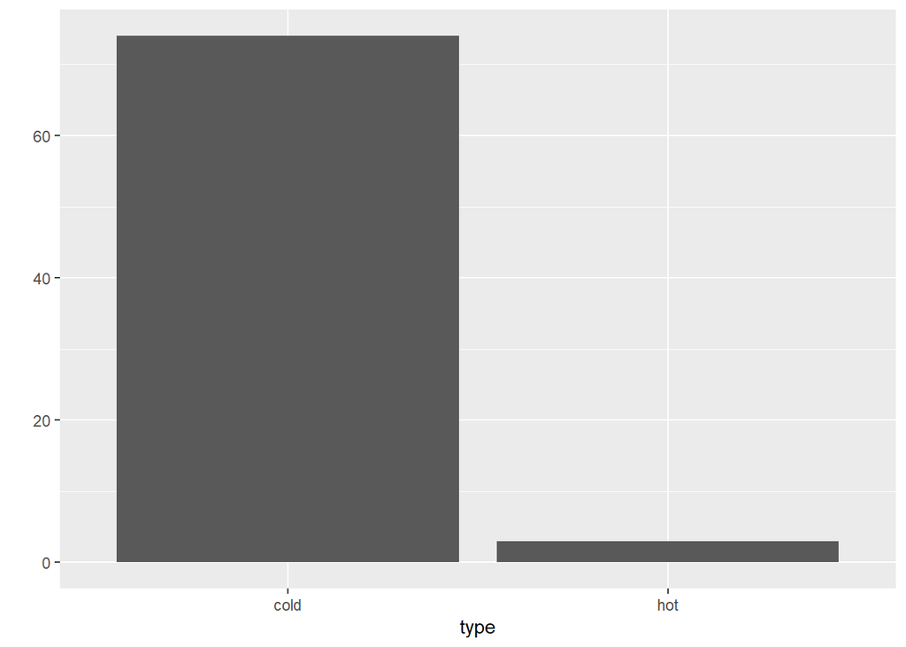

> ```r
> qplot(x = type, data = cereal, geom = "bar")
> ```

> **Part (c)**

> ```r
> describe_distribution(cereal, calories)
> ```

> ```
> Variable |   Mean |    SD | IQR |           Range | Skewness | Kurtosis |  n | n_Missing
> ----------------------------------------------------------------------------------------
> calories | 106.88 | 19.48 |  10 | [50.00, 160.00] |    -0.45 |     2.37 | 77 |         0
> ```

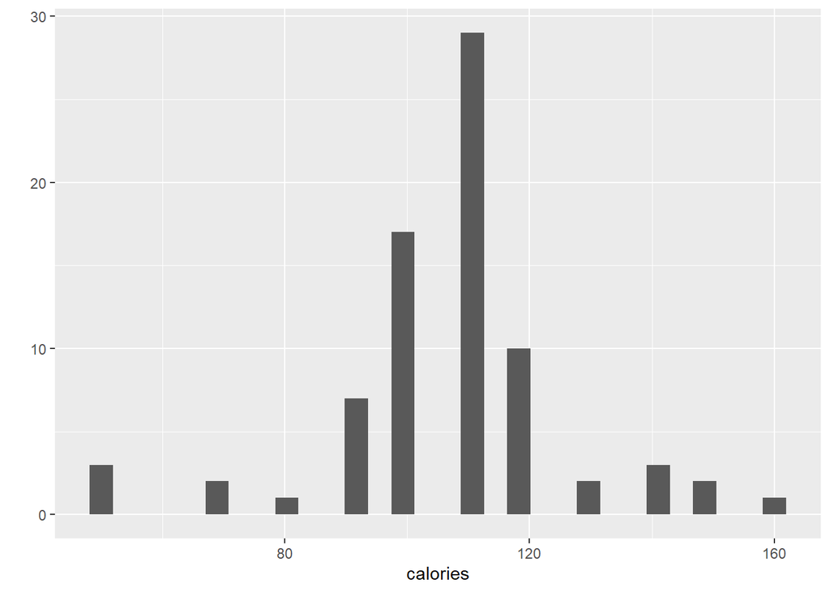

> ```r
> qplot(x = calories, data = cereal, geom = "histogram")
> ```

> **Part (d)**

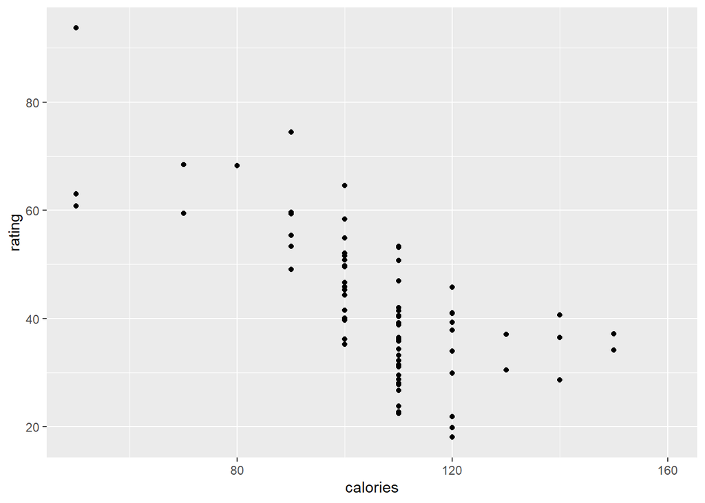

> ```r
> qplot(x = calories, y = rating, data = cereal, geom = "point")
> ```

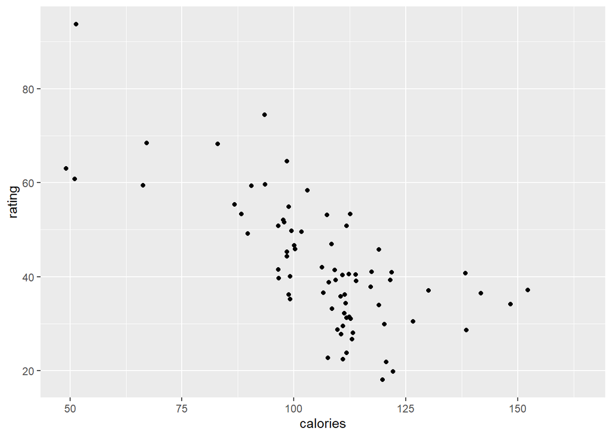

> ```r
> qplot(x = calories, y = rating, data = cereal, geom = "jitter")
> ```

*Note that there is no need to turn in Activities. These are just for practice!*